# Self-Driving Car Engineer Nanodegree

### 2.1.2 Perform Preprocessing

```python
# !!!
# First get originals (REFRESH, undo any previous pre-processing)
X_train, y_train = train['features'], train['labels']
X_valid, y_valid = valid['features'], valid['labels']
X_test, y_test = test['features'], test['labels']
```

```python
# !!! CHOOSE WHETHER OR NOT TO APPLY PREPROCESS !!!
# Convert dataset - takes a few seconds
# If merging, skip this and see below

apply_pre_process = False
if apply_pre_process:
    # Create transformed images (array of same shape as original but images lose a rank)
    # First create a list, then convert to array. Print shapes for reality check.
    X_train_new_list = []
    for image in X_train: #for image in X_train:
        new = pre_process(image,noise_=False,gray_=True,equalize_=False, center_=False)
        X_train_new_list.append(new)
    X_train_new_array = np.asarray(X_train_new_list)
    print("test shapes: ", X_train_new_array.shape, X_train.shape)

    X_valid_new_list = []
    for image in X_valid:
        new = pre_process(image,noise_=False,gray_=True,equalize_=False, center_=False)
        X_valid_new_list.append(new)
    X_valid_new_array = np.asarray(X_valid_new_list)
    print("valid shapes: ", X_valid_new_array.shape, X_valid.shape)

    X_test_new_list = []
    for image in X_test:
        new = pre_process(image,noise_=False,gray_=True,equalize_=False, center_=False)
        X_test_new_list.append(new)
    X_test_new_array = np.asarray(X_test_new_list)
    print("test shapes: ", X_test_new_array.shape, X_test.shape)
    print("Note whether gray has been applied or not for below")
```

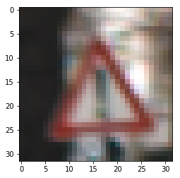

```python
# Visualise transformed signs (colorscale=hot, why not?) 1100
#plt.imshow(X_train_new_array[21000], cmap='gray')
plt.imshow(X_train[21000])
```

### 2.1.3 More advanced pre-processing

```
                                    Credit: Kessy, Lewin, Strimmer 2015 (2016)
                                    Optimal Whitening and Decorrelation
                                    Imperial \& Brunel
```

The idea is to transform a d-dimensional vector $x$ of mean $\mu$ and covariance matrix $\Sigma = X^T X$ to another d-dimensional vector $z=Wx$. The choice of $W$, the "whitening" matrix, depends on the desired transformation. z has the property $var(z)=I$, and if x has been zeroed then $E(z)=0$.

The simplest standardization is $Z=Wx$ where $W = V^{-\frac{1}{2}}$ and $V=diag(\sigma_{1}^2,...,\sigma_d^2)$ is the diagonal matrix of variances.

Note the identities of decomposition:

$\Sigma=V^\frac{1}{2} P V^\frac{1}{2}$ where $P$ is the correlation matrix and $V$ the diagonal covariance matrix;

and eigen-decomposition:

$\Sigma = U \Lambda U^T $ where $U$ is an eigenvector matrix and $\Lambda$ an eigenvalue (of $\Sigma$) matrix;

$P = G\Theta G^T$ where $G$ contains eigenvectors and $\Theta$ eigenvalues (of $P$).

The conclusions of the paper are as follows:

1. ZCA whitening $W = \Sigma\ ^ {-\frac{1}{2}}$;
2. ZCA-cor whitening (maximally similar to original) $W = P ^ {-\frac{1}{2}} V ^ {-\frac{1}{2}}$;
3. PCA-cor (maximally compressed original) $W = \Theta ^ {-\frac{1}{2}} G^T V ^ {-\frac{1}{2}} $.

### Data Augmentation

Some techniques for transformations (affine and other):

1. Translation
2. Small rotations
3. Colour transformations
4. Expanding
5. Add random noise
6. Blurring

Motivation:

1. Balancing training set (generate more data for the under-represented labels (see above) or trim over-)
2. Increase variance of training data to increase robustness of learned model

### Augment Data (Increase Data Size): Jittered Data (=merged then augmented)

1. Try only with affine operations
2. Try with random noise
3. Think about brightness and equalizing

```python
# Now we have a balanced set, with under-represented data points filled in by data generated using transform_image

# Generate Data

# Save new images and corresponding labels here
# later convert to arrays then concatenate with merged data and labels
extra_images_list = []
extra_labels_list = []

# Loop through images and corresponding labels, adding new image and label to new lists
for index, image in enumerate (merged_images): #NB: merged_labels[i] is label for merged_images[i]
    new_img = transform_image(image, ang_range=10, shear_range=5, trans_range=2, brightness=0)
    extra_images_list.append(new_img)
    extra_labels_list.append(merged_labels[index])
```

```
84399
84399
new:  16
CSV:  ['16' 'Vehicles over 3.5 metric tons prohibited']
```

[figure not shown]

```python
# Reality Check
print(len(extra_images_list))
print(len(extra_labels_list))

# Make sure images have correct label (see csv!), are different etc
i=45600
print('new: ', extra_labels_list[i]) #Eg y=36, corresponding to signnames[37,] = "go straight or right"
print('CSV: ', signnames[extra_labels_list[i]+1,])

# Get an original
check_i = -1
target = signnames[extra_labels_list[i]+1,][0]
#print(target)
for index, value in enumerate(y_train):
    if str(value) == target:
        check_i = index # use this for ref in X_train
        break

# Plot
fig = plt.figure(figsize=(8,16))

a = fig.add_subplot(121)
a.set_title("Generated")
plt.imshow(extra_images_list[i])

a = fig.add_subplot(122)
a.set_title("An Original")
plt.imshow(X_train[check_i])

plt.show()
```

```python
# Make new arrays, append to "merged" for input into keras
extra_images_array = np.asarray(extra_images_list)
extra_labels_array = np.asarray(extra_labels_list)

# Merge
jittered_images = np.concatenate((merged_images,extra_images_array),axis=0)
jittered_labels = np.concatenate((merged_labels,extra_labels_array),axis=0)
```

```python
# Reality Check
print(X_train.shape, generated_image_array.shape, merged_images.shape, jittered_images.shape)
print(y_train.shape, gen_labels_array.shape, merged_labels.shape, jittered_labels.shape)
```

```
(34799, 32, 32, 3) (49600, 32, 32, 3) (84399, 32, 32, 3) (168798, 32, 32, 3)
(34799,) (49600,) (84399,) (168798,)
```

### Model Architecture

```python
### Define your architecture here.
### Feel free to use as many code cells as needed.

import tensorflow as tf
from keras.models import Sequential
from keras.layers import Dropout
from keras.layers.convolutional import Convolution2D, MaxPooling2D
from keras.layers.core import Activation, Flatten, Dense
from keras.optimizers import SGD, Adam
from keras.utils import np_utils
```

```python
# Hyperparameters
learning_rate = 0.001 #0.001
n_epochs = 60
batch_size = 128

# Network params
n_classes = 43
dropout = 0.7
```

#### LeNet 1998 (later try resnet etc? inception)

in -> conv -> relu -> pool -> conv -> relu -> pool -> fc -> relu -> fc -> softmax -> out

in -> conv_1 -> pool_1 -> conv_2 -> pool_2 -> fc_1 -> fc_2 -> out

```python
# Credit: pyimagesearch.com - Adrian Rosebrock 2016 for architecture and code (edited for notebook)

# lenet.py

def build(width, height, depth, classes,
          weights_path=None):

    model = Sequential()

    #First conv-relu-pool chain
    model.add(Convolution2D(filters=16,kernel_size=(5,5),padding='same', input_shape=(height,width,depth),
                           data_format="channels_last")) # 20 filters
    model.add(Activation('relu'))
    model.add(MaxPooling2D(pool_size=(2,2), strides=(2,2))) # n = (n+2p-f)/s+1 = (32-2)/2+1 = 16 (2,2 always halves)

    #Second con-relu-pool chain
    model.add(Convolution2D(filters=32,kernel_size=(5,5),padding='same',
                           data_format="channels_first")) # NB new input_shape
    model.add(Activation('relu'))
    model.add(MaxPooling2D(pool_size=(2,2), strides=(2,2))) # n = (16-2)/2+1 = 8

    ##Third con-relu-pool chain 31/12/17 00:40
    #model.add(Convolution2D(filters=256,kernel_size=(5,5),padding='same',
    #                       data_format="channels_first")) # NB new input_shape, unspecified' 50 filters
    #model.add(Activation('relu'))
    #model.add(MaxPooling2D(pool_size=(2,2), strides=(2,2))) # n = (16-2)/2+1 = 8

    #Fully-connected layers
    model.add(Flatten())

    # Dropout
    model.add(Dropout(rate=dropout))

    # FC
    model.add(Dense(units=1256))
    model.add(Activation('relu'))

    # FC - experimental
    model.add(Dense(units=64))
    model.add(Activation('relu'))

    #Softmax classifier
    model.add(Dense(classes)) # penultimate layer, having 43 nodes
    model.add(Activation('softmax'))

    #Use any pre-loaded weights - activated if said argument supplied when build() is called
    if weights_path is not None:
        model.load_weights(weights_path)

    return model
```

```python
#from keras.utils import plot_model
#plot_model(model, to_file='model.png')
#needs pydot and graphviz
```

### Train, Validate and Test the Model

A validation set can be used to assess how well the model is performing. A low accuracy on the training and validation sets imply underfitting. A high accuracy on the training set but low accuracy on the validation set implies overfitting.

```python
### Train your model here.
### Calculate and report the accuracy on the training and validation set.
### Once a final model architecture is selected,
### the accuracy on the test set should be calculated and reported as well.
### Feel free to use as many code cells as needed.
```

### Skip if using jittered data ### Input Datasets

```python
# Skip if using jittered data
using_jittered_data=True
if using_jittered_data==False:
    # Define data including one-hot encoded labels
    trainData = merged_images #-128 #/255 #merged_images #np.asarray(generated_image_list)# X_train
    validData = X_valid #-128 #/255 #X_valid
    testData = X_test #-128 #/255 #X_test
    trainLabels = np_utils.to_categorical(merged_labels, 43) #(merged_labels,43) #(gen_labels_list), 43) #(y_train, 43)
    validLabels = np_utils.to_categorical(y_valid, 43)
    testLabels = np_utils.to_categorical(y_test, 43)
```

### Manual Dataset Selection & Processing (Merged then process)

NB Graying jittered data takes ages and causes my machine to slow down significantly even after execution.

```python
import timeit
```

```python
# Convert to gray manually

# Define data including one-hot encoded labels
t0 = timeit.default_timer()
trainData = np.sum(jittered_images/3,axis=3,keepdims=True) #np.sum(merged_images/3,axis=3,keepdims=True) #-128 #/255 #merged_images #np.asarray(generated_image_list)# X_train
t1 = timeit.default_timer() #720 seconds = 12 minutes (913 on a slow day)
print(t1-t0)
```

```
719.3544591719983
```

```python
validData = np.sum(X_valid/3,axis=3,keepdims=True)  #-128 #/255 #X_valid
t2 = timeit.default_timer()
testData = np.sum(X_test/3,axis=3,keepdims=True)   #-128 #/255 #X_test
t3 = timeit.default_timer()
print(t2-t1,t3-t2)
#trainLabels = np_utils.to_categorical(jittered_labels, 43) #(merged_labels,43) #(gen_labels_list), 43) #(y_train, 43)
#validLabels = np_utils.to_categorical(y_valid, 43)
#testLabels = np_utils.to_categorical(y_test, 43)
```

```
241.3037811130016 1.5121855249999498
```

```python
# IGNORE
ignore=True
if ignore==False:
    # regen, gray
    testData = np.sum(X_test/3,axis=3,keepdims=True)   #-128 #/255 #X_test
    # equalize
    new_test_list = []
    for img in testData:
        eq = cv2.equalizeHist(img.astype(np.uint8))
        img = eq[:,:,np.newaxis]
        new_test_list.append(img)

    testData = np.asarray(new_test_list)

    # noramlize
    mu3=np.mean(testData)
    print(mu3)#82 # 82.1
    testData = (testData-mu3)/mu3
```

[output not shown]

```python
trainLabels = np_utils.to_categorical(jittered_labels, 43) #(merged_labels,43) #(gen_labels_list), 43) #(y_train, 43)
validLabels = np_utils.to_categorical(y_valid, 43)
testLabels = np_utils.to_categorical(y_test, 43)

print(testData.shape, testLabels.shape, X_test.shape, y_test.shape)
```

```
(12630, 32, 32, 1) (12630, 43) (12630, 32, 32, 3) (12630,)
```

```python
# HISTOGRAM EQUALIZE

# original -> gray -> equalize -> reshape

# train then valid and test below

print('input dimension: ', trainData[0].shape)
print('input pixel ', trainData[0][15,21])
new_train_list = []
for img in trainData:
    eq = cv2.equalizeHist(img.astype(np.uint8)) # does re-typing to integer lose too much info? no, still 0-255 scale!
    img = eq[:,:,np.newaxis]
    new_train_list.append(img)
trainData = np.asarray(new_train_list)

#trainData = cv2.equalizeHist(trainData)
# do sth
print('output dimension: ', trainData[0].shape)
print('out pixel ', trainData[0][15,10])
```

```
input dimension:  (32, 32, 1)
input pixel  [ 80.]
output dimension:  (32, 32, 1)
out pixel  [243]
```

```python
new_valid_list = []
new_test_list = []

for img in validData:
    eq = cv2.equalizeHist(img.astype(np.uint8))
    img = eq[:,:,np.newaxis]
    new_valid_list.append(img)

validData = np.asarray(new_valid_list)

for img in testData:
    eq = cv2.equalizeHist(img.astype(np.uint8))
    img = eq[:,:,np.newaxis]
    new_test_list.append(img)

testData = np.asarray(new_test_list)
```

```python
# CENTER & NARROW (NORMALIZE)
mu1=np.mean(trainData)
mu2=np.mean(validData)
mu3=np.mean(testData)
print(mu1) #68 # 71.5 # 121 after gray then equal
print(mu2)#84 # 83.6 # 131
print(mu3)#82 # 82.1 # 131

trainData = (trainData-mu1)/mu1
validData = (validData-mu2)/mu2
testData = (testData-mu3)/mu3

# NB data now ready for model
```

```
121.18754718
131.468053784
131.626905882
```

### Start learning (get comfortable...)

Adjust "depth" if not grayscaling images.

```python
# lenet_mnist.py - command-line rather than notebook...

depth = 1
load_model = True
save_weights = False
input_path="/home/jesse//Documents/Udacity/Drafts/Traffic_Sign/CarND-Traffic-Sign-Classifier-Project/Weights_6.csv"
output_path="/home/jesse//Documents/Udacity/Drafts/Traffic_Sign/CarND-Traffic-Sign-Classifier-Project/Weights_7.csv"

import argparse
ap = argparse.ArgumentParser()
ap.add_argument("-s", "--save-model", type=int, default=-1,
                help="(optional) whether or note model should be saved to disk")
ap.add_argument("-l", "--load-model", type=int, default=-1,
               help="(optional) whether or not pre-trained model should be loaded")
ap.add_argument("-w", "--weights", type=str,
               help="(optional) path to weights file")
args = vars(ap.parse_args([])) # need [] to avoid error; "parse" not notebook-compatible

# Initialize optimizer and model
print("[INFO] compiling model...")
opt = Adam(lr=learning_rate)
model = build(width=32, height=32, depth=depth, classes=n_classes,
             weights_path=input_path) # depth=3 works for color
model.compile(loss="categorical_crossentropy", optimizer=opt,
             metrics=["accuracy"])

# Only train and evaluate the model if not loading pre-trained model
if load_model == False:
    print("[INFO] training...")
    model.fit(trainData, trainLabels, batch_size=batch_size, epochs=n_epochs, verbose=1)
    # Show accuracy on valid & test sets
    print("[INFO] evaluating")
    (loss, accuracy) = model.evaluate(validData, validLabels, batch_size=batch_size, verbose=1)
    print("[INFO] valid accuracy: ", accuracy*100)
    (loss, accuracy) = model.evaluate(testData, testLabels, batch_size=batch_size, verbose=1)
    print("[INFO] test accuracy: ", accuracy*100)

# Optional save
if save_weights == True:
    print("[INFO] saving...")
    model.save_weights(output_path, overwrite=False)




# One-Hot Encode Labels
#y_train_K = np_utils.to_categorical(y_train_K, 43)
#y_test_K = np_utils.to_categorical(y_test_K, 43)
```

```
[INFO] compiling model...
```

```python
(loss, accuracy) = model.evaluate(trainData, trainLabels, batch_size=batch_size, verbose=1)
```

```python
print("Train accuracy: ", accuracy)
```

```
Train accuracy:  0.993459638147
```

```python
# Show accuracy on valid & test sets
print("[INFO] evaluating")
(loss, accuracy) = model.evaluate(validData, validLabels, batch_size=batch_size, verbose=1)
print("[INFO] valid accuracy: ", accuracy*100)
(loss, accuracy) = model.evaluate(testData, testLabels, batch_size=batch_size, verbose=1)
print("[INFO] test accuracy: ", accuracy*100)
```

```
[INFO] evaluating
[INFO] valid accuracy:  93.6507936508
[INFO] test accuracy:  90.5067300259
```

### Performance Analysis

```python
#Subset for performance analysis
# define functions, then draw graph of accuracy vs code

def evaluate_subset(chosen_label_code = 23,X=trainData,y=trainLabels):
    subset_X = []; subset_y=[]
    for index, hot_vector in enumerate(y): # trainLabels is one-hot encoded already
        if np.argmax(hot_vector) == chosen_label_code:
            subset_X.append(X[index])
            subset_y.append(y[index])

    #print(len(subset_X), len(subset_y))
    subset_X_array = np.array(subset_X); subset_y_array = np.array(subset_y)
    #print(subset_X_array.shape, subset_y_array.shape)
    (loss, accuracy_test) = model.evaluate(subset_X_array, subset_y_array, batch_size=batch_size, verbose=1)
    #print(accuracy_test)
    return chosen_label_code, accuracy_test
```

```python
#evaluate_subset(chosen_label_code = 42,X=trainData,y=trainLabels)
#print(chosen_label_code, accuracy_test)
```

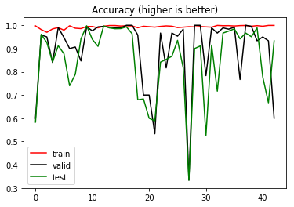

```python
# Analyse performance (default = valid data) - takes a couple of minutes
performance_analysis_train = []
performance_analysis_valid = []
performance_analysis_test = []

for i in range(n_classes):
    loss, accuracy_test = evaluate_subset(i,trainData,trainLabels)
    performance_analysis_train.append((i,accuracy_test))
    loss, accuracy_test = evaluate_subset(i,validData,validLabels)
    performance_analysis_valid.append((i,accuracy_test))
    loss, accuracy_test = evaluate_subset(i,testData,testLabels) # cheating?
    performance_analysis_test.append((i,accuracy_test))

# Plot results
perf_anal_array_train = np.array(performance_analysis_train)
perf_anal_array_valid = np.array(performance_analysis_valid)
perf_anal_array_test = np.array(performance_analysis_test)

plt.plot(perf_anal_array_train[:,1],'r', label='train')
plt.plot(perf_anal_array_valid[:,1],'black', label='valid')
plt.plot(perf_anal_array_test[:,1],'green', label='test')
plt.title("Accuracy (higher is better)")
plt.legend()
plt.show()
```

```python
print(np.mean(perf_anal_array_train[:,1])) #NB unweighted, but should be similar since I've balanced data
print(np.mean(perf_anal_array_valid[:,1]))
print(np.mean(perf_anal_array_test[:,1]))
```

```
0.993680960971
0.899077147061
0.852418958061
```

## Iterations Log

CNN20, CNN50, FC128-64-43. Merged data. Un-processed. No dropout.

1. 99.13,79,80 with new architecure (new FC layer, slightly changed nos), no pre-processing, jittered data
2. With all pre-processing: 80,40,37 - overfits for labels in 20s and 30s - this suggests making gen data more realistic and varied

CNN16, CNN32, D(0.7), FC128-64-43. Processed. Credit Medium.

1. With same gen data (half parameters), new archi and processed:
   1. Stuck at 2%!
2. Without dropout 29/12/17
   1. 69, 26, 25

CNN16, CNN32, FC128-64-43. Original data only, Un-pre-processed, no dropout.

1. 94, 79, 80 - not even learning to predict its own data. Having bigger Conv layers seemed to be better - let's confirm with all else equal.
2. 90s per epoch!

CNN20, CNN50, FC128-64-43. Original data only. Un-processed. No dropout.

1. 97, 80, 80
2. 150s per epoch

CNN20, CNN50, FC128-64-43. Original data only. Un-processed. No dropout. Adam instead of SGD. bacth 256

1. 98.62, 83.2, 83.7
2. Much faster. 80pc by epoch 2.
3. 137s an' all.
4. Interestingly, didn't do quite as well on training data but generalises better.
5. Weights saved as Weights.csv.

CNN16, CNN64, CNN256, FC256-128-43. Original data only. Un-processed. No dropout. Adam.

1. Stuck at 4.7%! Too big a machine (without skips or something).

CNN6, CNN16, FC128-64-43. batch 128

1. 98.25, 84.648, 84.972
2. Accuracy_breakdown_3.png

CNN6, CNN16, FC128-64-43. batch 128 - merged data

1. 98.95, 84.2, 83.0
2. 112s/epoch
3. Accuracy_breakdown_4.png

CNN6, CNN16, FC128-64-43. batch 128 - merged data + gray

1. 92, 49, 48
2. Much slower epoch 1 but good epoch 2
3. 80s
4. Why does uniform pre-processing worsen accuracy and generalizability?

CNN6, CNN16, FC128-64-43. batch 128 - merged data + manual-gray

1. 99.0, 85.6, 84.4

CNN6, CNN16, FC128-64-43. batch 128 - merged data + manual-gray + manual-normalize

1. 99.45, 85.7, 85.4

CNN6, CNN16, FC128-64-43. batch 128 - JITTERED data + manual-gray + manual-normalize

1. 87, 82, 83
2. 150s
3. Learning less but generalizing better? Accuracy_breakdown_8.png. Still not really learning some of the signs in the 20s. Perhaps the balancing examples weren't representative (but the addition of similarly-generated images resulting in improvements contradicts this). Maybe adding noise all round will help.
4. Data set has doubled (again) - this will have implications for the architecture.

CNN16, CNN32, FC128-64-43. batch 128 - JITTERED data + manual-gray + manual-normalize

1. 97.8, 89.7, 90.5

CNN16, CNN32, FC128-64-43. batch 128 - JITTERED data + manual-gray + equalize + manual-normalize (60 epochs)

CNN16, CNN32, FC1256-64-43. batch 128 - JITTERED data + manual-gray + equalize + manual-normalize (60 epochs)

1. 99, 93.65, 90 - good enough

Later: skip connection (don't use Sequential).

```python
model = build(width=32, height=32, depth=depth, classes=n_classes,
             weights_path=input_path) # depth=3 works for color
model.compile(loss="categorical_crossentropy", optimizer=opt,
             metrics=["accuracy"])
model.summary()
```

```
_________________________________________________________________
Layer (type)                 Output Shape              Param #
=================================================================
conv2d_9 (Conv2D)            (None, 32, 32, 16)        416
_________________________________________________________________
activation_16 (Activation)   (None, 32, 32, 16)        0
_________________________________________________________________
max_pooling2d_8 (MaxPooling2 (None, 16, 16, 16)        0
_________________________________________________________________
conv2d_10 (Conv2D)           (None, 32, 16, 16)        12832
_________________________________________________________________
activation_17 (Activation)   (None, 32, 16, 16)        0
_________________________________________________________________
max_pooling2d_9 (MaxPooling2 (None, 16, 8, 16)         0
_________________________________________________________________
flatten_4 (Flatten)          (None, 2048)              0
_________________________________________________________________
dropout_4 (Dropout)          (None, 2048)              0
_________________________________________________________________
dense_8 (Dense)              (None, 1256)              2573544
_________________________________________________________________
activation_18 (Activation)   (None, 1256)              0
_________________________________________________________________
dense_9 (Dense)              (None, 64)                80448
_________________________________________________________________
activation_19 (Activation)   (None, 64)                0
_________________________________________________________________
dense_10 (Dense)             (None, 43)                2795
_________________________________________________________________
activation_20 (Activation)   (None, 43)                0
=================================================================
Total params: 2,670,035
Trainable params: 2,670,035
Non-trainable params: 0
_________________________________________________________________
```

## Step 3: Test a Model on New Images

To give yourself more insight into how your model is working, download at least five pictures of German traffic signs from the web and use your model to predict the traffic sign type.

You may find `signnames.csv` useful as it contains mappings from the class id (integer) to the actual sign name.

### Load and Output the Images

```python
### Load the images and plot them here.
### Feel free to use as many code cells as needed.

### Define function for this
import cv2 as cv

def load_pics(folder):
    "Loads all pics from 'folder', returns list and prints failures by index."
    pics = []
    for index, img in enumerate (os.listdir(folder)):
        pic = cv2.imread(os.path.join(folder,img))
        if pic is not None:
            pic = pic[:, :, ::-1] # RGB <-> BGR, openCV-matplot clash!
            pics.append(pic)
            #print("Loaded image index: ", index)
        else:
            pass #print ("Failed to load index: ", index)
    print("Loaded ", len(pics), " photos.")
    return pics

# pred_test_img = cv2.imread("/home/jesse/Documents/Udacity/Drafts/Traffic_Sign/CarND-Traffic-Sign-Classifier-Project/Prediction_examples/p_main_street_has_right_of_way.jpg")
```

```
Loaded  5  photos.
```

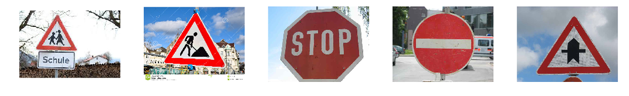

```python
### Load pics

folder = "/home/jesse/Documents/Udacity/Drafts/Traffic_Sign/CarND-Traffic-Sign-Classifier-Project/Prediction_examples/"
pics = load_pics(folder)

fig = plt.figure(figsize=(15,30))
for i in range(len(pics)):
    a = fig.add_subplot(1,len(pics),i+1)
    a.axis('off')
    plt.imshow(pics[i])
fig.tight_layout()
plt.show()
```

```python
### Define function for resizing pics

def resize_32_32(img):
    resized = cv2.resize(img, (32,32))
    return resized

def resize_list(ls):
    out = []
    for pic in ls:
        resized = resize_32_32(pic)
        out.append(resized)
    return out
```

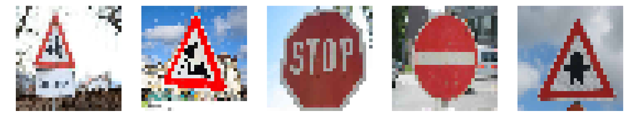

```python
### Resize pics
resized_list = resize_list(pics)

# Visualize
fig = plt.figure(figsize=(15,30))
for i in range(len(resized_list)):
    a = fig.add_subplot(1, len(resized_list), i+1)
    a.axis('off')
    a.imshow(resized_list[i])
fig.tight_layout()
plt.show()
```

```python
### Pre-process

### Define function

# original -> gray -> equalize -> reshape

def pre_process_manual(img):

    ## Gray
    p_gray = np.sum(img/3,axis=2,keepdims=True)
    #print(img.shape, p_gray.shape, p_gray.dtype)

    ## Equalize
    p_equalize = cv2.equalizeHist(p_gray.astype(np.uint8))
    #print(p_equalize.shape)
    p_equalize = p_equalize[:,:,np.newaxis] # put back the dimension compressed by cv2.equalizeHist
    #print(p_equalize.shape)

    ## Normalize
    mu = np.mean(p_equalize)
    p_norm = (p_equalize - mu) / mu
    #print(p_norm.shape)

    return p_norm

def process_list(ls):
    out = []
    for img in ls:
        pre_processed = pre_process_manual(img)
        out.append(pre_processed)
    return out
```

```python
### Do the pre-preocessing
pics_ready = process_list(resized_list)
```

### Predict the Sign Type for Each Image

```python
### Run the predictions here and use the model to output the prediction for each image.
### Make sure to pre-process the images with the same pre-processing pipeline used earlier.
### Feel free to use as many code cells as needed.

pred = model.predict_classes(x=np.array(pics_ready),batch_size=1)
```

```python
for prediction in pred:
    print(signnames[prediction+1,])
```

```
['25' 'Road work']
['21' 'Double curve']
['14' 'Stop']
['17' 'No entry']
['11' 'Right-of-way at the next intersection']
```

### Analyze Performance

```python
### Calculate the accuracy for these 5 new images.
### For example, if the model predicted 1 out of 5 signs correctly, it's 20% accurate on these new images.
```

I suspect that the strong background features in the second image - a beautiful blue sky with clouds, bright building with bold lines crossing the whole image - may have misled the model. We shall see in the further analysis below.

### Output Top 5 Softmax Probabilities For Each Image Found on the Web

For each of the new images, print out the model's softmax probabilities to show the **certainty** of the model's predictions (limit the output to the top 5 probabilities for each image). [`tf.nn.top_k`](https://www.tensorflow.org/versions/r0.12/api_docs/python/nn.html#top_k) could prove helpful here.

The example below demonstrates how tf.nn.top_k can be used to find the top k predictions for each image.

`tf.nn.top_k` will return the values and indices (class ids) of the top k predictions. So if k=3, for each sign, it'll return the 3 largest probabilities (out of a possible 43) and the correspoding class ids.

Take this numpy array as an example. The values in the array represent predictions. The array contains softmax probabilities for five candidate images with six possible classes. `tf.nn.top_k` is used to choose the three classes with the highest probability:

```
# (5, 6) array
a = np.array([[ 0.24879643,  0.07032244,  0.12641572,  0.34763842,  0.07893497,
         0.12789202],
       [ 0.28086119,  0.27569815,  0.08594638,  0.0178669 ,  0.18063401,
         0.15899337],
       [ 0.26076848,  0.23664738,  0.08020603,  0.07001922,  0.1134371 ,
         0.23892179],
       [ 0.11943333,  0.29198961,  0.02605103,  0.26234032,  0.1351348 ,
         0.16505091],
       [ 0.09561176,  0.34396535,  0.0643941 ,  0.16240774,  0.24206137,
         0.09155967]])
```

Running it through `sess.run(tf.nn.top_k(tf.constant(a), k=3))` produces:

```
TopKV2(values=array([[ 0.34763842,  0.24879643,  0.12789202],
       [ 0.28086119,  0.27569815,  0.18063401],
       [ 0.26076848,  0.23892179,  0.23664738],
       [ 0.29198961,  0.26234032,  0.16505091],
       [ 0.34396535,  0.24206137,  0.16240774]]), indices=array([[3, 0, 5],
       [0, 1, 4],
       [0, 5, 1],
       [1, 3, 5],
       [1, 4, 3]], dtype=int32))
```

Looking just at the first row we get `[ 0.34763842, 0.24879643, 0.12789202]`, you can confirm these are the 3 largest probabilities in `a`. You'll also notice `[3, 0, 5]` are the corresponding indices.

```python
### Print out the top five softmax probabilities for the predictions on the German traffic sign images found on the web.
### Feel free to use as many code cells as needed.

pred_1 = model.predict(x=np.array(pics_ready),batch_size=1) # 5 by 43

sess = tf.Session()
a = sess.run(tf.nn.top_k(tf.constant(pred_1), k=3))
a
```

```
TopKV2(values=array([[  4.39321071e-01,   2.57129669e-01,   5.77410795e-02],
       [  3.28744918e-01,   2.84495652e-01,   1.35852069e-01],
       [  8.66958737e-01,   2.75362991e-02,   2.20329352e-02],
       [  1.00000000e+00,   2.78813561e-12,   2.36161568e-12],
       [  9.76993203e-01,   1.64343193e-02,   3.40439356e-03]], dtype=float32), indices=array([[25, 11, 20],
       [21, 11, 31],
       [14, 35, 34],
       [17, 27, 14],
       [11, 30, 21]], dtype=int32))
```

## Discussion

For those the model predicted correctly it had very high certainty in its top 1 pick. For those images incorrectly classified, the predictions were suitably 'cautious'; returning probabilities below 50% (44% and 33%) expresses just how little conviction it had in the single class.

Below we visualize the features given attention in early layers in both success and fail cases from the newly downloaded photos.

```python
# Schule sign: what the model predicted
softmax_probabilities_1 = [25,11,20]
for i in softmax_probabilities_1:
    print(signnames[i+1,])
```

```
['25' 'Road work']
['11' 'Right-of-way at the next intersection']
['20' 'Dangerous curve to the right']
```

```python
# What these signs look like (if time)
```

```python
# Work in progress sign
softmax_probabilities_1 = [21,11,31]
for i in softmax_probabilities_1:
    print(signnames[i+1,])
```

```
['21' 'Double curve']
['11' 'Right-of-way at the next intersection']
['31' 'Wild animals crossing']
```

### Project Writeup

Once you have completed the code implementation, document your results in a project writeup using this [template](https://github.com/udacity/CarND-Traffic-Sign-Classifier-Project/blob/master/writeup_template.md) as a guide. The writeup can be in a markdown or pdf file.

## Step 4 (Optional): Visualize the Neural Network's State with Test Images

This Section is not required to complete but acts as an additional excersise for understaning the output of a neural network's weights. While neural networks can be a great learning device they are often referred to as a black box. We can understand what the weights of a neural network look like better by plotting their feature maps. After successfully training your neural network you can see what it's feature maps look like by plotting the output of the network's weight layers in response to a test stimuli image. From these plotted feature maps, it's possible to see what characteristics of an image the network finds interesting. For a sign, maybe the inner network feature maps react with high activation to the sign's boundary outline or to the contrast in the sign's painted symbol.

Provided for you below is the function code that allows you to get the visualization output of any tensorflow weight layer you want. The inputs to the function should be a stimuli image, one used during training or a new one you provided, and then the tensorflow variable name that represents the layer's state during the training process, for instance if you wanted to see what the LeNet lab's feature maps looked like for it's second convolutional layer you could enter conv2 as the tf_activation variable.

For an example of what feature map outputs look like, check out NVIDIA's results in their paper [End-to-End Deep Learning for Self-Driving Cars](https://devblogs.nvidia.com/parallelforall/deep-learning-self-driving-cars/) in the section Visualization of internal CNN State. NVIDIA was able to show that their network's inner weights had high activations to road boundary lines by comparing feature maps from an image with a clear path to one without. Try experimenting with a similar test to show that your trained network's weights are looking for interesting features, whether it's looking at differences in feature maps from images with or without a sign, or even what feature maps look like in a trained network vs a completely untrained one on the same sign image.

[figure not shown]

Your output should look something like this (above)

```python
### Visualize your network's feature maps here.
### Feel free to use as many code cells as needed.

# image_input: the test image being fed into the network to produce the feature maps
# tf_activation: should be a tf variable name used during your training procedure that represents the calculated state of a specific weight layer
# activation_min/max: can be used to view the activation contrast in more detail, by default matplot sets min and max to the actual min and max values of the output
# plt_num: used to plot out multiple different weight feature map sets on the same block, just extend the plt number for each new feature map entry

def outputFeatureMap(image_input, tf_activation, activation_min=-1, activation_max=-1 ,plt_num=1):
    # Here make sure to preprocess your image_input in a way your network expects
    # with size, normalization, ect if needed
    # image_input =
    # Note: x should be the same name as your network's tensorflow data placeholder variable
    # If you get an error tf_activation is not defined it may be having trouble accessing the variable from inside a function
    activation = tf_activation.eval(session=sess,feed_dict={x : image_input})
    featuremaps = activation.shape[3]
    plt.figure(plt_num, figsize=(15,15))
    for featuremap in range(featuremaps):
        plt.subplot(6,8, featuremap+1) # sets the number of feature maps to show on each row and column
        plt.title('FeatureMap ' + str(featuremap)) # displays the feature map number
        if activation_min != -1 & activation_max != -1:
            plt.imshow(activation[0,:,:, featuremap], interpolation="nearest", vmin =activation_min, vmax=activation_max, cmap="gray")
        elif activation_max != -1:
            plt.imshow(activation[0,:,:, featuremap], interpolation="nearest", vmax=activation_max, cmap="gray")
        elif activation_min !=-1:
            plt.imshow(activation[0,:,:, featuremap], interpolation="nearest", vmin=activation_min, cmap="gray")
        else:
            plt.imshow(activation[0,:,:, featuremap], interpolation="nearest", cmap="gray")
```

```python
# Visualize
# https://keras.io/getting-started/faq/#how-can-i-obtain-the-output-of-an-intermediate-layer

# Resizing from: https://github.com/yashk2810/Visualization-of-Convolutional-Layers/blob/
# choose any image to want by specifying the index


img_to_visualize = pics_ready[4]
print(img_to_visualize.shape)
# Keras requires the image to be in 4D
# So we add an extra dimension to it.
img_to_visualize = np.expand_dims(img_to_visualize, axis=0)
```

```
(32, 32, 1)
```

```python
from keras import backend as K

get_1st_layer_output = K.function([model.layers[0].input], [model.layers[1].output])
layer_output_1 = get_1st_layer_output([img_to_visualize])[0]

get_2nd_layer_output = K.function([model.layers[0].input], [model.layers[2].output])
layer_output_2 = get_2nd_layer_output([img_to_visualize])[0]

get_3rd_layer_output = K.function([model.layers[0].input], [model.layers[3].output])
layer_output_3 = get_3rd_layer_output([img_to_visualize])[0]

get_4th_layer_output = K.function([model.layers[0].input], [model.layers[4].output])
layer_output_4 = get_3rd_layer_output([img_to_visualize])[0]
```

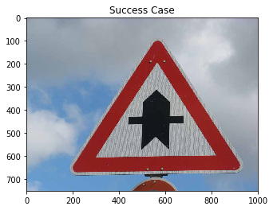

```python
plt.imshow(pics[4])
plt.title('Success Case')
plt.show()
```

```python
print(layer_output_1.shape)
print(layer_output_1[0].shape)

# Adjust for "channels last"
layer_output_1_reshaped = np.transpose(layer_output_1, axes=(0,3,1,2))
print(layer_output_1_reshaped.shape)
```

```
(1, 32, 32, 16)
(32, 32, 16)
(1, 16, 32, 32)
```

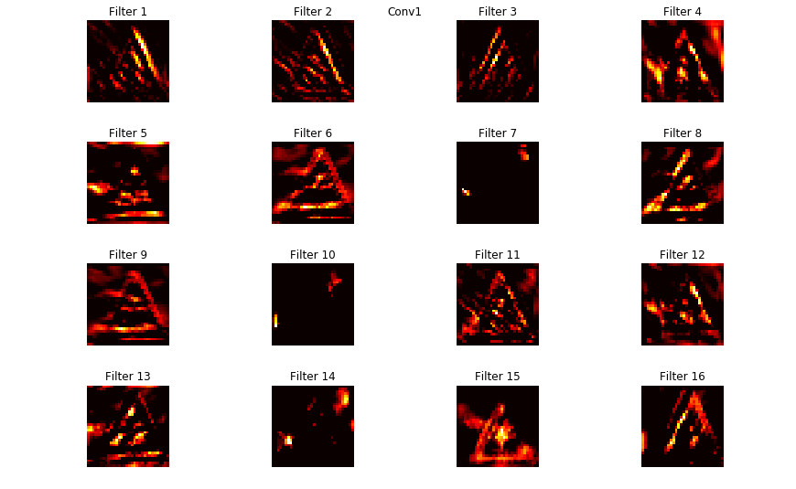

```python
fig = plt.figure(figsize=(12,8))
plt.title("Conv1")
plt.axis('off')
for i in range(layer_output_1_reshaped.shape[1]):
    a = fig.add_subplot(4, 4, i+1)
    a.axis('off')
    a.imshow(layer_output_1_reshaped[0][i], interpolation='nearest', cmap='hot')
    plt.title("Filter "+str(i+1))
fig.tight_layout()
plt.savefig('Success_Conv1.png')
plt.show()
```

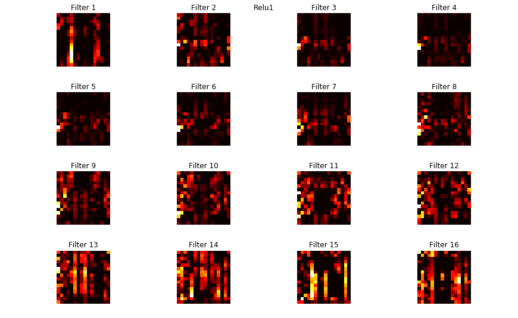

```python
fig = plt.figure(figsize=(12,8))
plt.title("Relu1")
plt.axis('off')
for i in range(layer_output_2.shape[1]):
    a = fig.add_subplot(4, 4, i+1)
    a.axis('off')
    a.imshow(layer_output_2[0][i], cmap='hot')
    plt.title('Filter '+str(i+1))
fig.tight_layout()
plt.show()
```

[figure not shown]

```python
fig = plt.figure(figsize=(12,8))
plt.title("Pool1")
plt.axis('off')
for i in range(layer_output_3.shape[1]):
    a = fig.add_subplot(4, 8, i+1)
    a.axis('off')
    a.imshow(layer_output_3[0][i], cmap='hot')
    plt.title('Filter '+str(i+1))
fig.tight_layout()
plt.show()
```

[figure not shown]

```python
fig = plt.figure(figsize=(12,8))
plt.title("Conv2")
plt.axis('off')
for i in range(layer_output_4.shape[1]):
    a = fig.add_subplot(4, 8, i+1)
    a.axis('off')
    a.imshow(layer_output_4[0][i], interpolation='nearest', vmin=-10, vmax=10, cmap='hot')
    plt.title('Filter ' + str(i+1))
fig.tight_layout()
plt.savefig('Success_Conv2.png')
plt.show()
```

```
(32, 32, 1)
```

[figure not shown]

```python
# Failure Case

# Redefine image of interest
img_to_visualize = pics_ready[1]
print(img_to_visualize.shape)
# Keras requires the image to be in 4D
# So we add an extra dimension to it.
img_to_visualize = np.expand_dims(img_to_visualize, axis=0)

plt.imshow(pics[1])
plt.title('Failure Case')
plt.axis('off')
plt.show()

# Get hidden features
layer_output_1 = get_1st_layer_output([img_to_visualize])[0]
# Adjust for "channels last"
layer_output_1_reshaped = np.transpose(layer_output_1, axes=(0,3,1,2))

layer_output_2 = get_2nd_layer_output([img_to_visualize])[0]

layer_output_3 = get_3rd_layer_output([img_to_visualize])[0]

layer_output_4 = get_3rd_layer_output([img_to_visualize])[0]
```

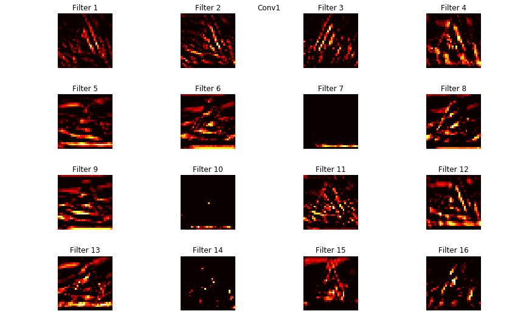

```python
fig = plt.figure(figsize=(12,8))
plt.title("Conv1")
plt.axis('off')
for i in range(layer_output_1_reshaped.shape[1]):
    a = fig.add_subplot(4, 4, i+1)
    a.axis('off')
    a.imshow(layer_output_1_reshaped[0][i], cmap='hot')
    plt.title("Filter "+str(i+1))
fig.tight_layout()
plt.savefig('Failure_Conv1.png')
plt.show()
```

[figure not shown]

```python
fig = plt.figure(figsize=(12,8))
plt.title("Conv2")
plt.axis('off')
for i in range(layer_output_4.shape[1]):
    a = fig.add_subplot(4, 8, i+1)
    a.axis('off')
    a.imshow(layer_output_4[0][i], interpolation='nearest', vmin=-10, vmax=10, cmap='hot')
    plt.title('Filter ' + str(i+1))
fig.tight_layout()
plt.savefig('Failure_Conv2.png')
plt.show()
```

## Discussion

The first filters are already failing to identify intrinsic features of the road sign and instead are picking up bold background features (and possibly the diagonal copyright mark). Compare filter 6 or 9 between the success and fail cases (at Conv1 layer), for example, to see how badly the model identifies sign borders in this case.

```
33449
['25' 'Road work'] 25
```

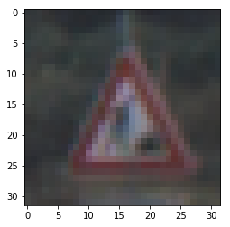

```python
# Retrieve another "work" example
for index, val in enumerate(y_train):
    if val == 25:
        print (index)
        break # => 33449
print(signnames[26,], y_train[33449])
plt.imshow(X_train[33449])
plt.show()
```